# MATHS1004 Mathematics for Data Science I

## Computer Lab 5

In this lab, we will do three very fun things.

1) We will download and analyze some text data.

2) We will use Naive Bayes to predict the author of some text.

3) We will try to generate new text that looks like a particular author.

Along the way we'll learn about:

- reading data into Python from a URL;
- dealing with strings;
- dictionaries! (Possibly **the best** aspect of using Python);
- problem-solving with messy data.

Here we go.

### Data wrangling

In this section we need to read a piece of text in, clean it, then create a list of words from it.

This is some *data wrangling* -- one of the essential aspects of practical data science. Actual data scientists say that wrangling data into a useable form is [80% of the job](https://www.nytimes.com/2014/08/18/technology/for-big-data-scientists-hurdle-to-insights-is-janitor-work.html)!

We'll need the following libraries, so load them up.

```python
import numpy as np  # Helps us do maths things!
import urllib.request  # Let's us get things from the internet
import re  # This is the `regular expressions' library. It helps us do string stuff.
from collections import Counter  # Counts things. That's all it does. Seriously.
```

`urrllib.request` allows you to access data directly from a URL. The following block loads a text file from the URL given, and then reads the first line. Run it to find out the dataset we'll be working with.

```python
URL = 'http://www.site.uottawa.ca/~lucia/courses/2131-02/A2/trythemsource.txt'

data = urllib.request.urlopen(URL)
data.readline()
```

```
b'"GREEN EGGS AND HAM" (by Doctor Seuss) \r\n'
```

Fun!!! Part of the reason this book is famous is because it [uses only 50 different words](https://en.wikipedia.org/wiki/Green_Eggs_and_Ham), making it perfect for exploring text generation.

The first thing you notice here is that we have a weird `b` before the string prints. A little bit of Googling will tell you that this means the string is encoded in a format called "UTF-8". This will cause us pain later on! So the first step will be to decode it to a regular ASCII string. Copy the last two commands above into the cell below, then put a `.decode('utf-8')` at the end of the `data.readline()` command, then execute.

```python
data = urllib.request.urlopen(URL)
data.readline().decode('utf-8')
```

```
'"GREEN EGGS AND HAM" (by Doctor Seuss) \r\n'
```

The `b` should be gone -- great! We now have an ASCII string.

Now, let's look at the whole document, line by line. Loop over the entire object `data`, and print each line. I'll start you off, then you fill in the rest of the loop.

```python
data = urllib.request.urlopen(URL) # Load in the data from the website again if you run this mutliple times.
data.readline().decode('utf-8') # Don't use data= data.readline().decode('utf-8')
for line in data:
    # Add code here
    print(line.decode('utf-8'))
```

```
I AM SAM. I AM SAM. SAM I AM.



THAT SAM-I-AM! THAT SAM-I-AM! I DO NOT LIKE THAT SAM-I-AM!



DO WOULD YOU LIKE GREEN EGGS AND HAM?



I DO NOT LIKE THEM,SAM-I-AM.

I DO NOT LIKE GREEN EGGS AND HAM.



WOULD YOU LIKE THEM HERE OR THERE?



I WOULD NOT LIKE THEM HERE OR THERE.

I WOULD NOT LIKE THEM ANYWHERE.

I DO NOT LIKE GREEN EGGS AND HAM.

I DO NOT LIKE THEM, SAM-I-AM.



WOULD YOU LIKE THEM IN A HOUSE?

WOULD YOU LIKE THEN WITH A MOUSE?



I DO NOT LIKE THEM IN A HOUSE.

```

[output cut: 210 more lines]

```
SO I WILL EAT THEM IN A BOX.

AND I WILL EAT THEM WITH A FOX.

AND I WILL EAT THEM IN A HOUSE.

AND I WILL EAT THEM WITH A MOUSE.

AND I WILL EAT THEM HERE AND THERE.

SAY! I WILL EAT THEM ANYWHERE!

I DO SO LIKE GREEN EGGS AND HAM!

THANK YOU! THANK YOU, SAM I AM.
```

To make the list of words we need for this project, the best thing to do is to first make this whole document into one long string. So we need to append each line into one string. Fortunately, you can do this in Python easily by adding strings. For example:a

```python
text = "Do you like green eggs and Ham?"
line = "I do not like them, Sam-I-Am."

text = text + line
print(text)
```

```
Do you like green eggs and Ham?I do not like them, Sam-I-Am.
```

(Question: How could you put in a space between the first and second sentences without changing them?)

Try using this idea to build your own variable `text` containing the entire document. We'll need to reload from the `URL`, so again I'll start you off. You fill in the rest of the `for` loop.

```python
data = urllib.request.urlopen(URL)
data.readline().decode('utf-8')

text = urllib.request.urlopen(URL)
text = text.readline().decode('utf-8')

for line in data:
    # Add each new line to the text
    print(line.decode('utf-8'))
```

```
I AM SAM. I AM SAM. SAM I AM.



THAT SAM-I-AM! THAT SAM-I-AM! I DO NOT LIKE THAT SAM-I-AM!



DO WOULD YOU LIKE GREEN EGGS AND HAM?



I DO NOT LIKE THEM,SAM-I-AM.

I DO NOT LIKE GREEN EGGS AND HAM.



WOULD YOU LIKE THEM HERE OR THERE?



I WOULD NOT LIKE THEM HERE OR THERE.

I WOULD NOT LIKE THEM ANYWHERE.

I DO NOT LIKE GREEN EGGS AND HAM.

I DO NOT LIKE THEM, SAM-I-AM.



WOULD YOU LIKE THEM IN A HOUSE?

WOULD YOU LIKE THEN WITH A MOUSE?



I DO NOT LIKE THEM IN A HOUSE.

```

[output cut: 210 more lines]

```
SO I WILL EAT THEM IN A BOX.

AND I WILL EAT THEM WITH A FOX.

AND I WILL EAT THEM IN A HOUSE.

AND I WILL EAT THEM WITH A MOUSE.

AND I WILL EAT THEM HERE AND THERE.

SAY! I WILL EAT THEM ANYWHERE!

I DO SO LIKE GREEN EGGS AND HAM!

THANK YOU! THANK YOU, SAM I AM.
```

If you got an error: did you decode each line to an ASCII string? Make sure you use the `decode` function.

Once you've got the long `text`, you still have two small things to clean up.

1) We have `\r`'s and `\n`'s all over the place! These are newline characters, which will put gaps in if you `print(text)` (try it). But they're a problem! You'll need to strip them out. Fortunately there's another helpful function: appending `.rstrip()` will strip out special characters from the right of a string, leaving us with only the text.

2) To do text generation we need to have *only* words, **no punctuation!** So we should replace every piece of punctuation with a space. We can use that `re` package to do it.

We've got a handy function here that will fix both of those issues. Call `remove_punctuation()` on each decoded line in the code above. This will remove all the fancy characters and leave us with just text.

`text` should now look like this:

`'I AM SAM I AM SAM SAM I AM THAT SAM...`

```python
def remove_punctuation(string_input):
    without_r_and_n = string_input.rstrip()
    without_punctuation = re.sub(r'[^\w\s]',' ',without_r_and_n)
    return without_punctuation
```

```python
data = urllib.request.urlopen(URL)
data.readline().decode('utf-8')

text = ''
for line in data:
    # Same as above, but now with remove_punctuation function as well
    text = text + remove_punctuation(line.decode('utf-8'))
text
```

```
'I AM SAM  I AM SAM  SAM I AM THAT SAM I AM  THAT SAM I AM  I DO NOT LIKE THAT SAM I AM DO WOULD YOU LIKE GREEN EGGS AND HAM I DO NOT LIKE THEM SAM I AM I DO NOT LIKE GREEN EGGS AND HAM WOULD YOU LIKE THEM HERE OR THERE I WOULD NOT LIKE THEM HERE OR THERE I WOULD NOT LIKE THEM ANYWHERE I DO NOT LIKE…
```

Let's convert everything to lower-case, by appending `.lower()` to the end of `text`.

```python
text = text.lower()
text
```

```
'i am sam  i am sam  sam i am that sam i am  that sam i am  i do not like that sam i am do would you like green eggs and ham i do not like them sam i am i do not like green eggs and ham would you like them here or there i would not like them here or there i would not like them anywhere i do not like…
```

Now. How many unique words are there in `text`? The code below splits `text` (by spaces) into a list of words. Then I create a set from that list (i.e., all the unique elements), and take the length. This gives the vocabulary size, or the number of unique words.

```python
words = text.split()
len(set(words))
```

```
54
```

I get 54 different words. What??? Where did those extra 4 words come from? Something is messy with the dataset itself, and we have to do some legit detective work to track the issue down. Here's how I figured it out. `Counter` creates a dictionary of how many times each item appears in a list. And `.most_common()` sorts that list from most to least common.

```python
Counter(words).most_common()
```

```
[('i', 83),
 ('not', 82),
 ('them', 59),
 ('a', 56),
 ('like', 44),
 ('in', 40),
 ('do', 37),
 ('you', 34),
 ('would', 27),
 ('and', 26),
 ('eat', 23),
 ('sam', 19),
 ('with', 18),
 ('will', 18),
 ('am', 16),
 ('could', 14),
 ('eggs', 11),
 ('ham', 11),
 ('here', 11),
 ('the', 11),
 ('green', 10),
 ('there', 9),
 ('or', 8),
 ('anywhere', 8),
 ('house', 8),
 ('train', 8),
 ('mouse', 7),
 ('box', 7),
 ('fox', 7),
 ('car', 7),
 ('dark', 7),
 ('tree', 6),
 ('on', 6),
 ('say', 5),
 ('so', 5),
 ('may', 4),
 ('see', 4),
 ('let', 4),
 ('me', 4),
 ('be', 4),
 ('rain', 4),
 ('goat', 4),
 ('try', 4),
 ('that', 3),
 ('boat', 3),
 ('they', 2),
 ('are', 2),
 ('good', 2),
 ('thank', 2),
 ('then', 1),
 ('greem', 1),
 ('if', 1),
 ('he', 1),
 ('tries', 1)]
```

Once you've figured it out, go ahead and `.replace` those two words with what they ought to be! Then check that the vocabulary size is in fact 50 words. I'll help you out with two of them.

```python
words
```

```
['i',
 'am',
 'sam',
 'i',
 'am',
 'sam',
 'sam',
 'i',
 'am',
 'that',
 'sam',
 'i',
 'am',
 'that',
 'sam',
 'i',
 'am',
 'i',
 'do',
 'not',
 'like',
 'that',
 'sam',
 'i',
 'am',
 'do',
 'would',
 'you',
 'like',
 'green',
 'eggs',
 'and',
 'ham',
 'i',
 'do',
 'not',
 'like',
 'them',
 'sam',
 'i',
```

[output cut: 744 more lines]

```
 'i',
 'do',
 'so',
 'like',
 'green',
 'eggs',
 'and',
 'ham',
 'thank',
 'you',
 'thank',
 'you',
 'sam',
 'i',
 'am']
```

```python
text = text.replace('then','them')  # A spelling error
text = text.replace(' he ',' ')  # Shouldn't be in the text
# # Add two more here!
text = text.replace('sam','abby')  # A spelling error
text = text.replace('like','hate')
words = text.split()
len(set(words)) # Use this to test if you have 50 words
```

```
52
```

```python
words
```

```
['i',
 'am',
 'abby',
 'i',
 'am',
 'abby',
 'abby',
 'i',
 'am',
 'that',
 'abby',
 'i',
 'am',
 'that',
 'abby',
 'i',
 'am',
 'i',
 'do',
 'not',
 'hate',
 'that',
 'abby',
 'i',
 'am',
 'do',
 'would',
 'you',
 'hate',
 'green',
 'eggs',
 'and',
 'ham',
 'i',
 'do',
 'not',
 'hate',
 'them',
 'abby',
 'i',
```

[output cut: 743 more lines]

```
 'i',
 'do',
 'so',
 'hate',
 'green',
 'eggs',
 'and',
 'ham',
 'thank',
 'you',
 'thank',
 'you',
 'abby',
 'i',
 'am']
```

Now we can do cool stuff with this text data. Let's start with something easy. **A histogram**. Make sure you set the `bins =50` in the `hist`.

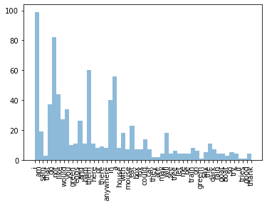

```python
# Add plots here, and don't forget to import
import matplotlib.pyplot as plt

plt.hist(words,alpha=0.5,bins = 50)

plt.xticks(rotation='vertical') # This will help rotate the labels (called xticks) on the bottom.
plt.show()
```